# Data Manipulation and Cleaning with Tidyverse

## Tidyverse

- **Tidyverse** is a collection of R packages designed for data science.
- It provides a consistent set of functions and syntax for data manipulation and visualization.
- Key packages include `dplyr`, `ggplot2`, `tidyr`, and `readr`.
  - `dplyr`: data manipulation
  - `ggplot2`: data visualization
  - `tidyr`: data cleaning
  - `readr`: data import
- Use `install.packages("tidyverse")` to install the package.
- Use `library(tidyverse)` to load the packages.

## dplyr — core verbs

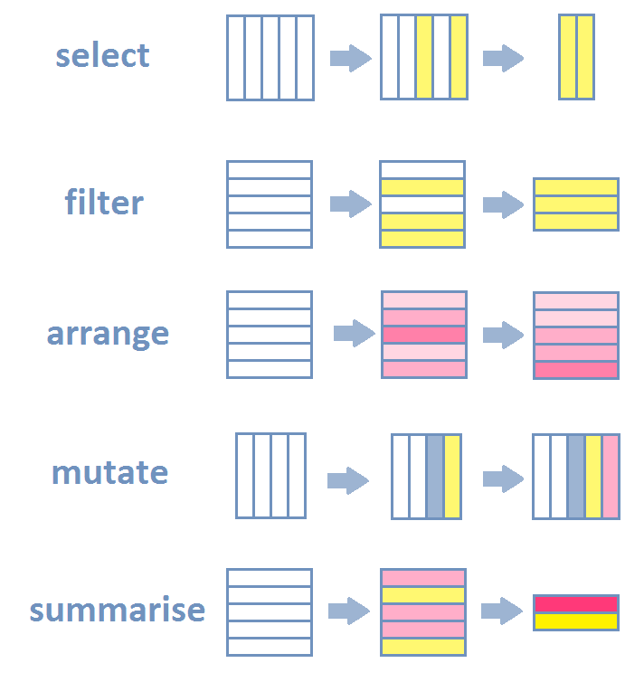

## Tidyverse `reader` package

- The `readr` package provides functions for reading data into R.
- The functions are similar to base R functions like `read.csv()`, but faster and more user-friendly.
- Common functions:
  - `read_csv()`: reads comma-separated files.
  - `read_tsv()`: reads tab-separated files.
  - `read_delim()`: reads files with custom delimiters.
  - `read_fwf()`: reads fixed-width files.
  - `read_table()`: reads tabular data.
- Returns a `tibble`, a modern version of a data frame.

## Sample data

```r
library(tidyverse)

df <- tibble(
  `Gene Description` = c("Protein kinase C (alpha)",
                         "Ribosomal protein L2",
                         "ATP synthase", "Control gene"),
  `Gene Accession Number` = c("Gene1", "Gene2", "Gene3", "AFFX-Control"),
  Sample1 = c(5.2, 3.4, 7.8, 1.2),
  call1 = c("P", "A", "P", "A"),
  Sample2 = c(5.5, 3.8, 8.0, 1.3),
  call2 = c("P", "A", "P", "A")
)
```

## Sample data (cont’d)

```r
print(dim(df))
```

```
[1] 4 6
```

```r
print(colnames(df))
```

```
[1] "Gene Description"      "Gene Accession Number" "Sample1"
[4] "call1"                 "Sample2"               "call2"
```

```r
print(head(df))
```

```
# A tibble: 4 × 6
  `Gene Description`       `Gene Accession Number` Sample1 call1 Sample2 call2
  <chr>                    <chr>                     <dbl> <chr>   <dbl> <chr>
1 Protein kinase C (alpha) Gene1                       5.2 P         5.5 P
2 Ribosomal protein L2     Gene2                       3.4 A         3.8 A
3 ATP synthase             Gene3                       7.8 P         8   P
4 Control gene             AFFX-Control                1.2 A         1.3 A
```

## Using the Pipe Operator: `%>%`

- The `%>%` operator passes the result of one function into the next.

```r
s <- rnorm(100)
m <- mean(s)

# Using the pipe operator
m <- s %>% mean()
# or
m <- rnorm(100) %>% mean()
# is equivalent to
m <- mean(rnorm(100))
```

## Using the Pipe Operator (%>%)

- Here, we select the “Gene Description” column and then display its head.

```r
df %>%
  select(`Gene Description`) %>%
  head()
```

```
# A tibble: 4 × 1
  `Gene Description`
  <chr>
1 Protein kinase C (alpha)
2 Ribosomal protein L2
3 ATP synthase
4 Control gene
```

```r
# This is equivalent to
head(select(df, `Gene Description`))
```

```
# A tibble: 4 × 1
  `Gene Description`
  <chr>
1 Protein kinase C (alpha)
2 Ribosomal protein L2
3 ATP synthase
4 Control gene
```

## `select()` function (dplyr package)

- The `select()` function is used to select columns from a data frame.
- Syntax: `select(data, column1, column2, ...)`
- Use `-` to exclude columns.
- Use `everything()` to include all remaining columns.
- Use `starts_with()`, `ends_with()`, `contains()`, `matches()` to select by name patterns.
- See `?select` for more details.

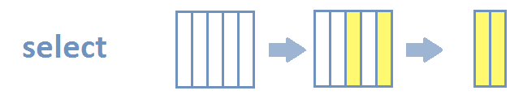

## `select()` function examples

```r
# Select columns by name
df %>%
  select(`Gene Description`, `Gene Accession Number`) %>%
  head()
```

```
# A tibble: 4 × 2
  `Gene Description`       `Gene Accession Number`
  <chr>                    <chr>
1 Protein kinase C (alpha) Gene1
2 Ribosomal protein L2     Gene2
3 ATP synthase             Gene3
4 Control gene             AFFX-Control
```

## `select()` function examples

```r
# Remove columns using `-`
df %>%
  select(-`Gene Description`, -`Gene Accession Number`) %>%
  head()
```

```
# A tibble: 4 × 4
  Sample1 call1 Sample2 call2
    <dbl> <chr>   <dbl> <chr>
1     5.2 P         5.5 P
2     3.4 A         3.8 A
3     7.8 P         8   P
4     1.2 A         1.3 A
```

```r
# Remove columns using `-` and contains()
df %>%
  select(-contains("call")) %>%
  head()
```

```
# A tibble: 4 × 4
  `Gene Description`       `Gene Accession Number` Sample1 Sample2
  <chr>                    <chr>                     <dbl>   <dbl>
1 Protein kinase C (alpha) Gene1                       5.2     5.5
2 Ribosomal protein L2     Gene2                       3.4     3.8
3 ATP synthase             Gene3                       7.8     8
4 Control gene             AFFX-Control                1.2     1.3
```

> 📝 **Task 1** — remove columns whose names start with `"call"` using `starts_with()`

## Filtering rows with `filter()` function

- `filter()` is used to select rows based on conditions.
- Syntax: `filter(data, condition)`
- Use logical operators: `==`, `!=`, `>`, `<`, `>=`, `<=`, `%in%`, `&`, `|`, `!`
- Use `between()` to filter rows within a range.

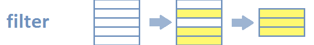

```r
kinase_df <- df %>%
  filter(str_detect(`Gene Description`, "kinase"))
print(kinase_df)
```

```
# A tibble: 1 × 6
  `Gene Description`       `Gene Accession Number` Sample1 call1 Sample2 call2
  <chr>                    <chr>                     <dbl> <chr>   <dbl> <chr>
1 Protein kinase C (alpha) Gene1                       5.2 P         5.5 P
```

> 📝 **Task 2** — filter `df` to keep only rows where `Sample1 > 4`

## Creating new columns with `mutate()` function

- `mutate()` is used to create new columns or modify existing columns.
- Syntax: `mutate(data, new_column = expression)`

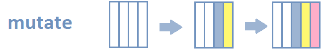

```r
df_extended <- df %>%
  mutate(IsControl = str_detect(`Gene Accession Number`, "^AFFX"))
print(df_extended)
```

```
# A tibble: 4 × 7
  `Gene Description`       `Gene Accession Number` Sample1 call1 Sample2 call2
  <chr>                    <chr>                     <dbl> <chr>   <dbl> <chr>
1 Protein kinase C (alpha) Gene1                       5.2 P         5.5 P
2 Ribosomal protein L2     Gene2                       3.4 A         3.8 A
3 ATP synthase             Gene3                       7.8 P         8   P
4 Control gene             AFFX-Control                1.2 A         1.3 A
# ℹ 1 more variable: IsControl <lgl>
```

## Using `mutate()` to create new columns

- Calculate the average expression across Sample1 and Sample2.

```r
df_extended <- df_extended %>%
  mutate(AvgExpr = rowMeans(select(., Sample1, Sample2), na.rm = TRUE))
print(df_extended)
```

```
# A tibble: 4 × 8
  `Gene Description`       `Gene Accession Number` Sample1 call1 Sample2 call2
  <chr>                    <chr>                     <dbl> <chr>   <dbl> <chr>
1 Protein kinase C (alpha) Gene1                       5.2 P         5.5 P
2 Ribosomal protein L2     Gene2                       3.4 A         3.8 A
3 ATP synthase             Gene3                       7.8 P         8   P
4 Control gene             AFFX-Control                1.2 A         1.3 A
# ℹ 2 more variables: IsControl <lgl>, AvgExpr <dbl>
```

> 📝 **Task 3** — add a column `"HighExpr"` that is `TRUE` when `AvgExpr > 5`

## Grouping and summarizing with `group_by()` and `summarize()`

- `group_by()` groups data by one or more variables.
- `summarize()` calculates summary statistics for each group.
- Use `ungroup()` to remove grouping.

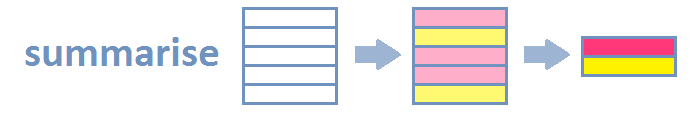

## `group_by()` — splits data into groups

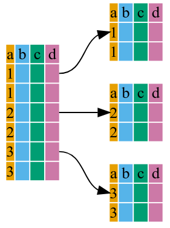

```r
by_cyl <- mtcars %>% group_by(cyl)
# Grouping does not change the data frame (it just adds a grouping attribute)
print(by_cyl)
```

```
# A tibble: 32 × 11
# Groups:   cyl [3]
     mpg   cyl  disp    hp  drat    wt  qsec    vs    am  gear  carb
   <dbl> <dbl> <dbl> <dbl> <dbl> <dbl> <dbl> <dbl> <dbl> <dbl> <dbl>
 1  21       6  160    110  3.9   2.62  16.5     0     1     4     4
 2  21       6  160    110  3.9   2.88  17.0     0     1     4     4
 3  22.8     4  108     93  3.85  2.32  18.6     1     1     4     1
 4  21.4     6  258    110  3.08  3.22  19.4     1     0     3     1
 5  18.7     8  360    175  3.15  3.44  17.0     0     0     3     2
 6  18.1     6  225    105  2.76  3.46  20.2     1     0     3     1
 7  14.3     8  360    245  3.21  3.57  15.8     0     0     3     4
 8  24.4     4  147.    62  3.69  3.19  20       1     0     4     2
 9  22.8     4  141.    95  3.92  3.15  22.9     1     0     4     2
10  19.2     6  168.   123  3.92  3.44  18.3     1     0     4     4
# ℹ 22 more rows
```

## Grouping changes the behavior of functions

```r
by_cyl <- mtcars %>% group_by(cyl) %>%
  summarize(mean_mpg = mean(mpg))
print(by_cyl)
```

```
# A tibble: 3 × 2
    cyl mean_mpg
  <dbl>    <dbl>
1     4     26.7
2     6     19.7
3     8     15.1
```

```r
by_cyl_gear <- mtcars %>% group_by(cyl, gear) %>%
  summarize(mean_mpg = mean(mpg))
print(by_cyl_gear)
```

```
# A tibble: 8 × 3
# Groups:   cyl [3]
    cyl  gear mean_mpg
  <dbl> <dbl>    <dbl>
1     4     3     21.5
2     4     4     26.9
3     4     5     28.2
4     6     3     19.8
5     6     4     19.8
6     6     5     19.7
7     8     3     15.0
8     8     5     15.4
```

## Grouping (cont’d)

```r
control_summary <- df_extended %>%
  group_by(IsControl) %>%
  summarize(mean_expr = mean(AvgExpr), sd_expr = sd(AvgExpr))
print(control_summary)
```

```
# A tibble: 2 × 3
  IsControl mean_expr sd_expr
  <lgl>         <dbl>   <dbl>
1 FALSE          5.62    2.16
2 TRUE           1.25   NA
```

> 📝 **Task 4** — calculate median horsepower (`hp`) per cylinder count in `mtcars`

## Reshaping data with `pivot_longer()` and `pivot_wider()` functions

- `pivot_longer()`: converts wide data to long data.
- `pivot_wider()`: converts long data to wide data.
- Wide data: multiple columns for each variable.
- Long data: multiple rows for each variable.

## Wide format example

```r
wide_df <- tibble(
  ID = c(1, 2, 3, 4),
  Gene = c("Gene1", "Gene2", "Gene3", "Gene4"),
  Expr1 = c(5.2, 3.4, 7.8, 1.2),
  Expr2 = c(5.5, 3.8, 8.0, 1.3),
  Expr3 = c(5.5, 3.8, 8.0, 1.3),
  Expr4 = c(5.5, 3.8, 8.0, 1.3),
  Expr5 = c(5.5, 3.8, 8.0, 1.3)
)
print(wide_df)
```

```
# A tibble: 4 × 7
     ID Gene  Expr1 Expr2 Expr3 Expr4 Expr5
  <dbl> <chr> <dbl> <dbl> <dbl> <dbl> <dbl>
1     1 Gene1   5.2   5.5   5.5   5.5   5.5
2     2 Gene2   3.4   3.8   3.8   3.8   3.8
3     3 Gene3   7.8   8     8     8     8
4     4 Gene4   1.2   1.3   1.3   1.3   1.3
```

## Long format example

- `pivot_longer(data, cols, names_to, values_to)`
  - `cols`: columns to pivot.
  - `names_to`: new column that stores original column names.
  - `values_to`: new column that stores the values.

```r
long_df <- wide_df %>%
  pivot_longer(cols = starts_with("Expr"),
               names_to = "Sample",
               values_to = "Expression")
print(long_df)
```

```
# A tibble: 20 × 4
      ID Gene  Sample Expression
   <dbl> <chr> <chr>       <dbl>
 1     1 Gene1 Expr1         5.2
 2     1 Gene1 Expr2         5.5
 3     1 Gene1 Expr3         5.5
 4     1 Gene1 Expr4         5.5
 5     1 Gene1 Expr5         5.5
 6     2 Gene2 Expr1         3.4
 7     2 Gene2 Expr2         3.8
 8     2 Gene2 Expr3         3.8
 9     2 Gene2 Expr4         3.8
10     2 Gene2 Expr5         3.8
11     3 Gene3 Expr1         7.8
12     3 Gene3 Expr2         8
13     3 Gene3 Expr3         8
14     3 Gene3 Expr4         8
15     3 Gene3 Expr5         8
16     4 Gene4 Expr1         1.2
17     4 Gene4 Expr2         1.3
18     4 Gene4 Expr3         1.3
19     4 Gene4 Expr4         1.3
20     4 Gene4 Expr5         1.3
```

## `pivot_longer()` — example

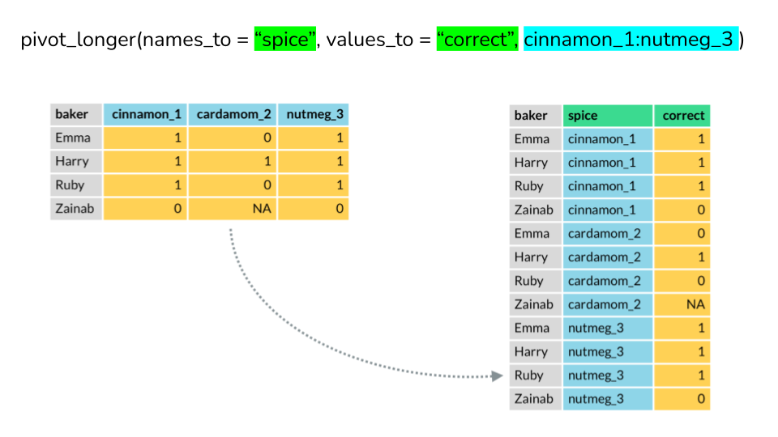

## Converting long data to wide data

- `pivot_wider(data, names_from, values_from)`
  - `names_from`: column whose values become new column names.
  - `values_from`: column whose values fill the new columns.

```r
wide_df <- long_df %>%
  pivot_wider(names_from = "Sample",
              values_from = "Expression")
print(wide_df)
```

```
# A tibble: 4 × 7
     ID Gene  Expr1 Expr2 Expr3 Expr4 Expr5
  <dbl> <chr> <dbl> <dbl> <dbl> <dbl> <dbl>
1     1 Gene1   5.2   5.5   5.5   5.5   5.5
2     2 Gene2   3.4   3.8   3.8   3.8   3.8
3     3 Gene3   7.8   8     8     8     8
4     4 Gene4   1.2   1.3   1.3   1.3   1.3
```

> 📝 **Task 5** — add a `log2Expr` column to `long_df`, then pivot back to wide format

## Data joining with `left_join()`, `right_join()`, `inner_join()`, and `full_join()`

- `left_join()`: all rows from left + matched rows from right.
- `right_join()`: all rows from right + matched rows from left.
- `inner_join()`: only rows with matching values in both tables.
- `full_join()`: all rows from either table.

## Types of joins

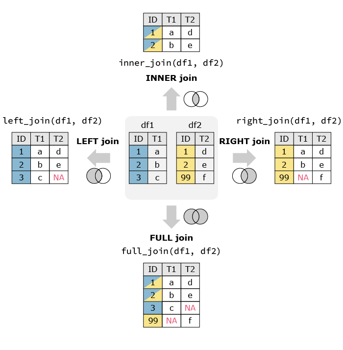